# Math 190 Final Project

Vraj Patel

5/7/19

# Introduction

Enron was a company that showed tremendous growth and was considered one of the most innovative countries of the time in the 1990s. At around the time of the dot-com economy crash, it was revealed that Enron, through partnerships with other companies, was hiding huge debts and losses. Their equity values was several billion less than what its balance sheet said and Arther Andersen, the company contracted as Enron’s accountants was most likely complicit in the fraud (Background information taken from https://www.npr.org/news/specials/enron/.) I chose this data set as I found I had an interest in social networks, especially in analyzing the results of the various community detection methods. I believe the community detection functions will have some interesting results and I hope that disinct communities will emerge that can represent the various departments of people that worked in the company such as legal and R&D. I am particularly looking forward to seeing a community in the center of the network that represents the executives of the company as they would logically be the ones who were the primary progeniters of the fraud that took place.

# Prior Work

The Enron corpus was made public during the legal investigation of the Enron corporation and has subsequently been thoroughly researched within academia including the field of network data science. A group of researchers based in Carnegie Mellon University cleaned the Enron Corpus of duplicate and unnecessary data. They then analyzed scatterplots of the data and saw that messages are distributed exponentially amongst the employees of Enron and observed that a small percentage of users comprise of the majority of email with one person nearing 100,000 emails alone. These researchers were also faced with the task of determining the significance of email threads as larger threads hold more information but can also be succeptible to redundant information. These researchers concluded by saying that one way the data can be used is to better evaluate email classification methods (https://bklimt.com/papers/2004_klimt_ceas.pdf). Another group of researchers at Columbia University developed an algorithm to detect the social hierarhy of users in the data based on the contents of the email. Some metrics used to develop the model include the average response times for emails and by using cliques. The latter was accomplished by creating an undirected network graph from the dataset and using community detection methods to determine the cliques. Using that algoritm researchers were able to reproduce the top of Enron’s corporate ladder with great accuracy, but that accuracy did not extend to lower ranked employees. It is important to note, however, that the algorithm is able to accurately identify the 2-3 most important people in a subset of data (https://academiccommons.columbia.edu/doi/10.7916/D83F4XJ9).

# Data

The Enron corpus originially contained the contents of the emails and attachments, but a group of researchers at Carnegie Mellon University (https://bklimt.com/papers/2004_klimt_ceas.pdf and https://www.cs.cmu.edu/~enron/) streamlined the data so that duplicates were removed and it could be easily translated to network data. This data was then taken by another group of researchers (https://arxiv.org/pdf/0810.1355.pdf) who further streamlined to be network data and a large list of directed and unweighted edges with 36,692 nodes and 183,831 edges (there are double the entries in the igraph object as it isa directed graph. It was then publicly posted by the Stanford Network Analysis Project in a format easily usable as network data (http://snap.stanford.edu/data/email-Enron.html.) It originally came as space delimited which I converted into a csv file to be easily read into R with the “readr” library. This dataset is obviously very large and and takes up 14 megabytes as an igraph object in R. Using a simple plot function takes well over 5 minutes to compute and results in a picture without qualitative meaning. Therefore other methods will have to be used to create the network diagrams while the igraph library in R will be used primarily for calculations.

# Methods

My main goal when attempting to analyze thhis data was to use community detection methods and try to potentially identify communities that could’ve been more involved in the making of the scandal such as executives. In order to do this I modified the original data set so that insignificant nodes were removed and the Louvain community detection algorithm would only affect the significant nodes thus leading to more significant communties. I removed insignificant nodes by testing the community sizes of the data set if nodes of varying degrees were removed. This method resulted in a very intersting graph in gephi where one community was connected to all the other communities in a hierarchical format giving the sense that they were the most important nodes as they had strong connections to each of the other communities. After employing the community detection algorithm, I ventured farther into the SAND with R book and viewed the coreness measurements for both the original network and the modified network with the degree cutoff. From these graph objects, I was able to create coreness networks which gave a hierarchical overview of the nodes that were the most connected. Through the layout of the colors, one can identify the most significant ID numbers of people that had the most connections. From there, I was able to print these nodes and identify the ID numbers of those that were most connected and most significant in the Enron scandal.

# Results

```r
library(readr)
Email_Enron = read_csv("C:/Users/Vraj/Documents/Second Semester/Math 190/Email-Enron.csv")
library(igraph)
enron = graph.data.frame(Email_Enron[-c(1,2,3),]) # removes leading columns that describe the data set and do not contain actual nodes but are treated as nodes and edges by R
summary(enron)
enron.u = as.undirected(enron)
summary(enron.u)
set.seed(42)
```

```r
graph.density(enron.u)
transitivity(enron.u)
diameter(enron.u)
average.path.length(enron.u)
vertex.connectivity(enron.u)
edge.connectivity(enron.u)
```

[output not shown]

```r
enron.l = cluster_louvain(enron.u)
length(enron.l)
```

[output not shown]

The Louvain community detection method shows that there are 1319 communities. This is obviously a very large number and deviates heavily from what I believed to be a very small number as I believed the community detection algorithm would be able to detect the various departments at Enron. We will see later that many of these communities are small clusters of one or just a couple nodes.

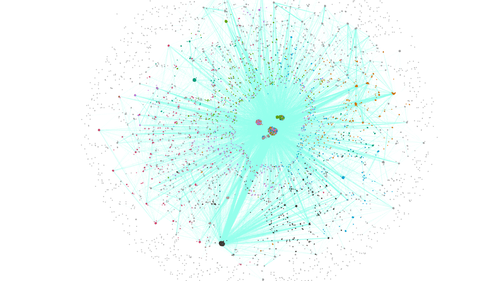

Complete Network

```r
hist(degree(enron), xlab = "Degree", col="lightblue", ylab = "Frequency", main = "Original Degree Distribution - Directed")
hist(degree(enron.u), xlab = "Degree", col="lightblue", ylab = "Frequency", main = "Original Degree Distribution - Undirected")

enron.2 = delete.vertices(enron, V(enron)[degree(enron)<=100])
hist(degree(enron.2), xlab = "Degree", col="lightblue", ylab = "Frequency", main = "Modified Degree Distribution - Directed")

enron.u2 = delete.vertices(enron.u, V(enron.u)[degree(enron.u)<=100])
hist(degree(enron.u2), xlab = "Degree", col="lightblue", ylab = "Frequency", main = "Modified Degree Distribution - Undirected")
```

[output not shown]

The first two histograms are the same as the underlying undirected graph is the same. The latter two is where things begin to change. For those, I graphed subgraphs that removed any nodes with degrees less than or equal to 100 so that insignificant nodes would be removed. I chose this number arbritarily to experiment and see how the distribution would change. We can see that the modified directed distribution is more strongly right skewed that the modified undirected distribution which is also skewed but shows a resemblance to a bell curve.

```r
d = 1:max(degree(enron.u))-1
ind = (degree.distribution(enron.u) != 0)
plot(d[ind], jitter(degree.distribution(enron.u)[ind]), log="xy", col="blue", xlab=c("Log-Degree"), ylab=c("Log-Intensity"), main="Log-Log Degree Distribution - Original Undirected")
```

[output not shown]

The log-log degree distribution shows us that there are a nontrivial amount of nodes with high degrees that would be important to focus on.

```r
hist(transitivity(enron, type="local"), col = "blue", xlab = "Local Clustering Coefficient", main = "Original Local Clustering Coefficient Distribution - Directed")
hist(transitivity(enron, type="local"), col = "blue", xlab = "Local Clustering Coefficient", main = "Original Local Clustering Coefficient Distribution - Directed")
```

[output not shown]

The distribution of local clustering coefficients show us that there are many nodes that are simply not well connected to the graph and furthermore that pretty much all the nodes in the graph are not that well connected.

```r
enron.u2 = delete.vertices(enron.u, V(enron.u)[degree(enron.u)<=67])
summary(enron.u2)

enron.l2 = cluster_louvain(enron.u2)
length(enron.l2)
modularity(enron.l2)
plot(enron.l2, enron.u2, vertex.size = 5, edge.size = 1, vertex.label=NA, main = "Community Plot - Degree Cutoff of 67")
```

[output not shown]

After removing nodes with degrees less than or equal to 1, 2, and 5, I decided to arbritarily remove those less than 67. I think doing this will help by keeping computations small, quick, and focused on the people most involved. The 6 communities that are isolated are an interesting result as well as they disappear with higher degree limit.

```r
enron.u3 = delete.vertices(enron.u, V(enron.u)[degree(enron.u)<=15])
summary(enron.u3)

enron.l3 = cluster_louvain(enron.u3)
length(enron.l3)
modularity(enron.l3)
plot(enron.l3, enron.u3, vertex.label= NA, vertex.size = 7.5, edge.size = 2, main = "Community Plot - Degree Cutoff of 15")
```

[output not shown]

I chose another arbritary number to compare the difference in connectedness between this and the previous graph. Removing nodes with low degrees seems to splinter the graph excessively. I was unable to find a way to make this graph connected so below was my solution.

```r
for (i in 1:40){
  # paste(i,length(cluster_louvain(delete.vertices(enron.u, V(enron.u)[degree(enron.u)<=i]))), collapse=":")
  print(i)
  print(length(cluster_louvain(delete.vertices(enron.u, V(enron.u)[degree(enron.u)<i]))))
}
```

[output not shown]

I ran this for loop to try and determine the degree cutoff I should use. My aim was to find a cutoff where the number of communities was stable. For example, there are large drops in the amounts of communities until about a degree value of 14, so I will be using that for further community detection here and in gephi. I will be referring to these igraph objects as enron.u14 and enron.l14 to represent the truncated undirected object and the same object after the Louvain community detection methods have been applied. In a practical sense, this is a logical move as in a dataset as large as this, those who only know such a low number, such as 14 others, would likely not have a significant part in the development of the scandal. While on that track, a logical and pertinent question is why choose 14 as the stopping point. My answer to that is 14 seems like a good middle ground in terms of removing those that did not have a significant contribution to the company

```r
enron.u14 = delete.vertices(enron.u, V(enron.u)[degree(enron.u)<14])
summary(enron.u14)

enron.l14 = cluster_louvain(enron.u14)
length(enron.l14)
modularity(enron.l14)

sizes(enron.l14)
```

[output not shown]

I loaded the enron.u14 into gephi and tried to make a network diagram with the different communities but quickly discovered that many of the communities had an insignificant number of nodes in regards to the data as a whole. This basically invalidates many of the code chunks I ran above and shows that I need to find a degree cutoff where no communities have a low number of members such as the many above that are communities of 1 or 2. The next chunks will be me attempting to find a better degree cutoff.

```r
for (i in 14:40){ # start at 14 because that is where I stopped last time
  # paste(i,length(cluster_louvain(delete.vertices(enron.u, V(enron.u)[degree(enron.u)<=i]))), collapse=":")
  print(i)
  print(length(cluster_louvain(delete.vertices(enron.u, V(enron.u)[degree(enron.u)<i]))))
  print(sizes(cluster_louvain(delete.vertices(enron.u, V(enron.u)[degree(enron.u)<i]))))
}
```

[output not shown]

In order to find the best degree cutoff, I ran another for loop with varying degree cutoffs and had it output the community sizes it would create. I aimed to select a degree cutoff that would lead me with the least number of solitary communities. That method would also, in theory, minimize the disconnected nodes in the graph. I will be settling on a degree cutoff of 30 now as it has only 6 communities with only one node in it. I am hoping this will be a temporary solution until I can find a way to determine the nodes that are solo communities and remove them.

```r
enron.u30 = delete.vertices(enron.u, V(enron.u)[degree(enron.u)<30])
summary(enron.u30)

enron.l30 = cluster_louvain(enron.u30)
length(enron.l30)
modularity(enron.l30)
```

[output not shown]

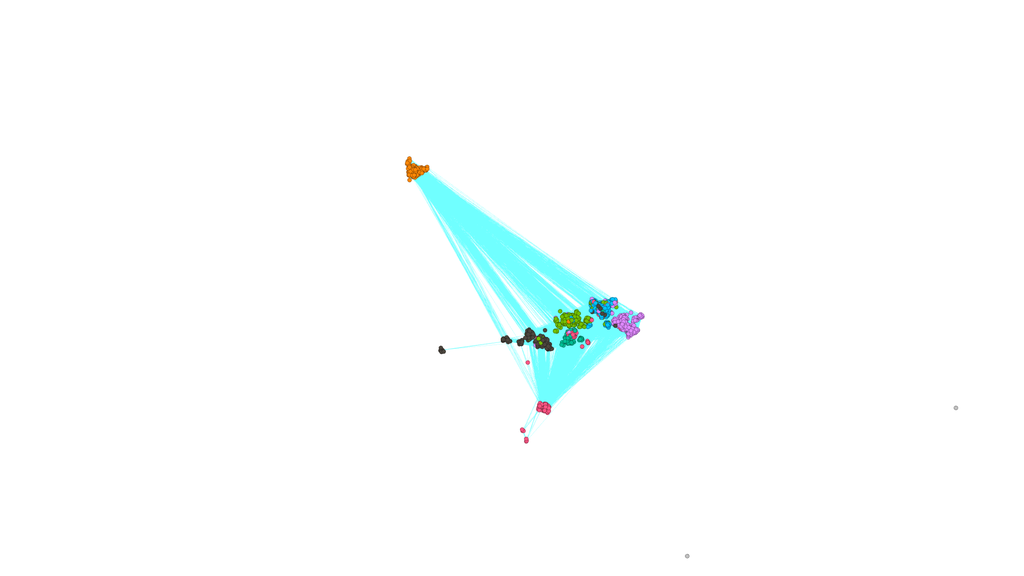

Truncated Network

```r
graph.density(enron.u30)
transitivity(enron.u30)
diameter(enron.u30)
average.path.length(enron.u30)
vertex.connectivity(enron.u30)
edge.connectivity(enron.u30)
```

[output not shown]

The density and transitivity for this model are higher than the one with 14 as the degree cutoff menaing the graph is more dense and nodes that weren’t too connected with other nodes were removed.

```r
hist(transitivity(enron.u30, type="local"), col = "blue", xlab = "Local Clustering Coefficient", main = "Local Clustering Coefficient Distribution - Undirected w/ Cutoff of 30")
```

[output not shown]

The new data set has a normally shaped local clustering coefficient distribution centered near 0.4. There is no longer a spike of nodes that have transitivity values of 0 and we can even see some nodes have values of 1.0.

```r
d = 1:max(degree(enron.u30))-1
ind = (degree.distribution(enron.u30) != 0)

plot(d[ind], jitter(degree.distribution(enron.u30)[ind]), log="xy", col="blue", xlab=c("Log-Degree"), ylab=c("Log-Intensity"), main="Log-Log Degree Distribution - Undirected with Cutoff of 30")
```

[output not shown]

The log-log degree distribution for the Enron network with the degree cutoff of 30 has an unusually shaped graph. There seem to be a few straggling nodes without a high degree towards the left and the right side, after the log-degree of 20 mark, looks more representative of the same type of graph earlier.

```r
enron.cores.30 = graph.coreness(enron.u30)
enron.cores = graph.coreness(enron.u)

summary(enron.cores.30)
summary(enron.cores)

hist(enron.cores, xlab = "Degree", col = "darkgreen", main = "Original Undirected Coreness Distribution")
hist(enron.cores.30, xlab = "Degree", col = "darkgreen", main = "Truncated Undirected Coreness Distribution")
```

[output not shown]

Here I created two objects that contain the coreness data for the undirected Enron igraph objects without a degree cutoff and with the degree cutoff of 30. The original has a very strong right skew due to the large amount of sparse nodes but has a small blip at the end of the x-axis with a cluster of nodes of degrees higher than 40 revealing themselves. The second histogram with the degree cutoff shows the nodes with the higher degrees through the left skew. The degree cutoff evidently did not leave many unconnected nodes.

```r
CorenessLayout = function(g) {
  coreness = graph.coreness(g);
  xy = array(NA, dim=c(length(coreness), 2));
  shells = sort(unique(coreness));
  for(shell in shells) {
    v = 1 - ((shell-1) / max(shells));
    nodes_in_shell = sum(coreness==shell);
    angles = seq(0,360,(360/nodes_in_shell));
    angles = angles[-length(angles)]; #  remove last element
    xy[coreness==shell, 1] = sin(angles) * v;
    xy[coreness==shell, 2] = cos(angles) * v;
  }
  return(xy);
}
```

The code from this chunk and the two below were taken from https://jcasasr.wordpress.com/2015/02/03/plotting-the-coreness-of-a-network-with-r-and-igraph/. This code produces visuals similar to the gplot.target function in the Social Network Analysis library but is much simpler in computing complexity. It does not actually compute centrality but I believe the visuals it produces are similar to what the gplot.target function would produce.

```r
#  assign colors
colbar = rainbow(max(coreness))
#  create layout
ll = CorenessLayout(enron.u)
plot(enron.u, layout=ll, vertex.size=2, vertex.label = NA, vertex.color=colbar[enron.cores], vertex.frame.color=colbar[enron.cores], main='Full Network Coreness')
```

[output not shown]

The plot above is the entire network. The deeper you go into the graph the higher the coreness of the nodes and the more connected they are. The colors give a sense of clear hierarchy between varying levels of coreness and in all it is a very useful graph, in my opinion, in determining how involved a person was in the Enron scandal.

```r
#  assign colors
colbar = rainbow(max(coreness))
#  create layout
l2 = CorenessLayout(enron.u30)
plot(enron.u30, layout=l2, vertex.size=3, vertex.label = NA, vertex.color=colbar[enron.cores.30], vertex.frame.color=colbar[enron.cores.30], main='Degree Cutoff Network Coreness')
```

[output not shown]

The above plot was made in the same way as the previous plot but had the network with the degree cutoff as the underlying igraph object. Both plots share the same hierarchical coreness measurements but the outer levels are extremely clustered and do not have the same level of organization as the inner levels. The first plot should contain the same information in terms of hierarchical importance and involvement, especially as you go closer to the center.

```r
max(enron.cores)
maxCoreVerticies = which(enron.cores == max(enron.cores))
colbar = rainbow(max(enron.cores))
kcore = induced.subgraph(graph=enron.u ,vids=maxCoreVerticies)
summary(kcore)

plot(kcore,index=V(kcore), layout = CorenessLayout(enron.u), vertex.label = NA, vertex.size = 2, edge.size = 1, edge.color = "lightblue", vertex.color=colbar[enron.cores], vertex.frame.color=colbar[enron.cores], main="Nodes of Max Level of Coreness - Original Network Object")
```

[output not shown]

Code adapted from https://stackoverflow.com/questions/19744335/how-to-use-graph-coreness-to-find-the-largest-k-core-the-vertex-belongs-to.

I created this plot by adapting two sources, the former for the layout and the latter for inducing the subgraph. It contains all the nodes in the graph that have a coreness of 43, the max coreness. There are clearly some levels in this graph as well which indicates levels of importance or involvement in the scandal. It is important to note that this network is missing many nodes from the counterpart graph it shares a similarity in appearance with.

```r
max(enron.cores.30)
maxCoreVerticies2 = which(enron.cores.30 == max(enron.cores.30))
colbar = rainbow(max(enron.cores.30))
kcore2 = induced.subgraph(graph=enron.u30, vids=maxCoreVerticies2)
summary(kcore2)

plot(kcore2,index=V(kcore2), layout = CorenessLayout(enron.u30), vertex.label = NA, vertex.size = 2.6, edge.size = 3, edge.color = "lightblue", vertex.color=colbar[enron.cores.30], vertex.frame.color=colbar[enron.cores.30], main="Nodes of Max Level of Coreness - Degree Cutoff Network Object")
```

[output not shown]

This network diagram shares the same characteristics as the one above except it was done with the igraph object created with a degree cutoff. As the previous two groups of graphs this one shares a similar structure in hierarchy as the one prior to it in the center. However there are many nodes that are splintered off which I find odd as they should have a coreness of 43 and be well connected in theory. There are two focal points in this network diagram that are not the center. These are at the right and at the top, which is more prominent and seems to be pulling the focal point towards it. The nodes at the center of these focal points would be interesting to focus on and compare with the nodes at the center to gauge involvement in the company’s affairs.

```r
maxCoreVerticies
```

[output not shown]

```r
maxCoreVerticies2
```

[output not shown]

The maxCoreVertices and maxCoreVertices2 objects have the same first nodes in them but their connecting does not often match. Nevertheless they contain the same principal nodes which are notably in common between these objects.

# Discussion

The Enron email data set is full of potential. What I did in this notebook barely scratched the surface. For instance, I was limited by my data set using numbers as identifications for people and thus could not find out the names of people responsible for the debacle. Had there been names instead of numbers I’m sure I would have been able to compare who I found were the people most responsible for the scandal and compare it to what the verdicts were in reality. However, from what I gathered online, the only way to obtain such data is to compile it by myself using the orignial Enron corpus which, I must unfortunately say, I do not yet have the acumen to perform such a task.

As I touched on above, this data has been heavily studied and has been used to create community detection models. This data set is one of the few of its kind in that it represents a corporate network through entirely digital communications. I would even go as far to say that the work I did is trivial to what can be done with data of this scale. For example, as I mentioned above, a group of researchers were able to determine an algorithm that could accurately identify the people that were most influential in a network similar to this. Unfortunately, this algorithm became significantly less accurate the lower down the corporate ladder it tried to predict but it still laid a basis for improvement. With the right tools, I believe that an algorithm can be made to use keywords and linguistic trends to more accurately predict a person’s position and rank within a social network. Such an algorithm would be astronomical and have endless applications from determining the severity of foreign threats by gathering information spread or by adapting computers to better identify human speaking traits and mannerisms.

# References

### Introduction

https://www.npr.org/news/specials/enron/

### Prior Work

https://bklimt.com/papers/2004_klimt_ceas.pdf https://academiccommons.columbia.edu/doi/10.7916/D83F4XJ9

### Data

https://bklimt.com/papers/2004_klimt_ceas.pdf https://www.cs.cmu.edu/~enron/ https://arxiv.org/pdf/0810.1355.pdf http://snap.stanford.edu/data/email-Enron.html

### Results

https://jcasasr.wordpress.com/2015/02/03/plotting-the-coreness-of-a-network-with-r-and-igraph/ https://stackoverflow.com/questions/19744335/how-to-use-graph-coreness-to-find-the-largest-k-core-the-vertex-belongs-to